# VLM Wrong Predictions: attr_decking_material

Asset 128273 3 images

Predicted: Steel (conf: N/A)

Actual: Timber

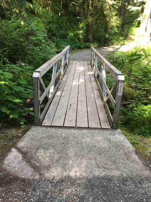

90332__AST_EX_20220617_171132.jpeg

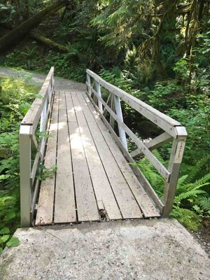

90331__AST_EX_20220617_171114.jpeg

[figure not shown]

90333__AST_EX_20220617_171150.jpeg

Asset 58183 2 images

Predicted: Concrete (conf: N/A)

Actual: Timber

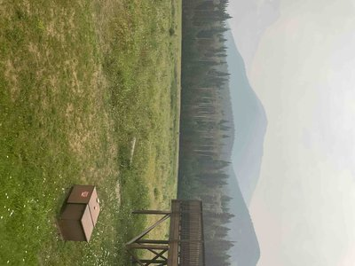

6494__AST_EX_20210715_120442.jpeg

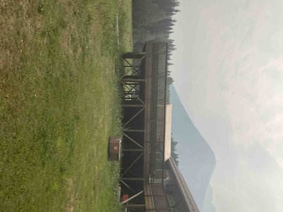

6495__AST_EX_20210715_120427.jpeg

Asset 123389 2 images

Predicted: Composite (conf: N/A)

Actual: Timber

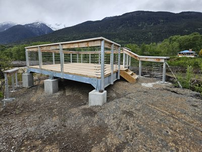

77613__Gitwinksihlkw_Viewing_Platform.jpg

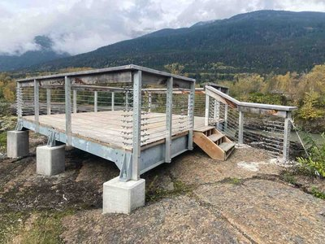

88342__AST_EX_20250918_123812.jpeg

Asset 103626 3 images

Predicted: Steel (conf: N/A)

Actual: Timber

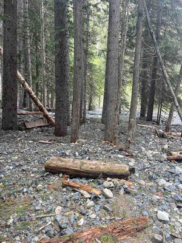

48406__AST_IM_20220622_115150.jpeg

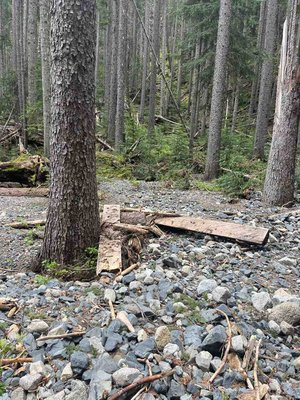

48407__AST_IM_20220622_115138.jpeg

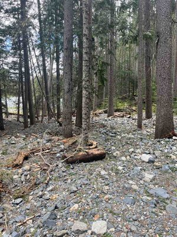

48408__AST_IM_20220622_115119.jpeg

Asset 49062 3 images

Predicted: Timber (conf: N/A)

Actual: Asphalt

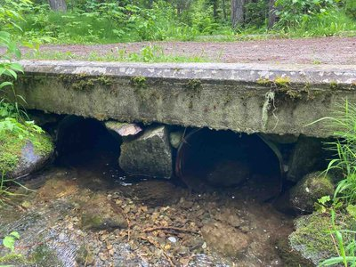

52782__AST_EX_20220707_102209.jpeg

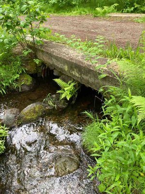

52802__AST_EX_20220707_102138.jpeg

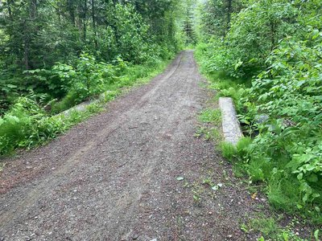

52829__AST_EX_20220707_102122.jpeg

Asset 55116 1 image

Predicted: Steel (conf: N/A)

Actual: Timber

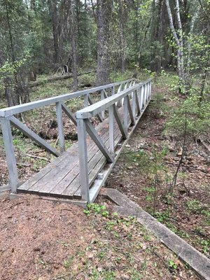

42069__AST_EX_20220518_141051.jpeg

Asset 67205 4 images

Predicted: Concrete (conf: N/A)

Actual: Timber

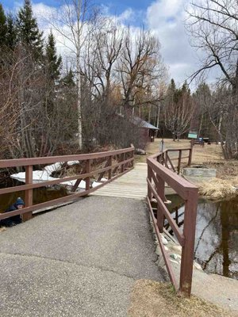

38565__AST_EX_20220331_144231.jpeg

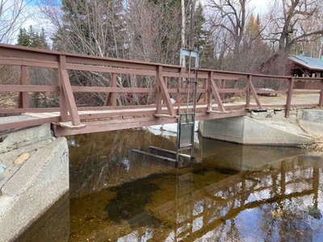

38570__AST_EX_20220331_144247.jpeg

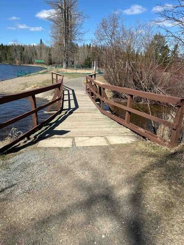

93110__AST_EX_20260422_114842.jpeg

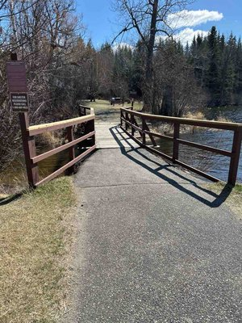

93111__AST_EX_20260422_114908.jpeg

Asset 107955 1 image

Predicted: Aluminum (conf: N/A)

Actual: Steel

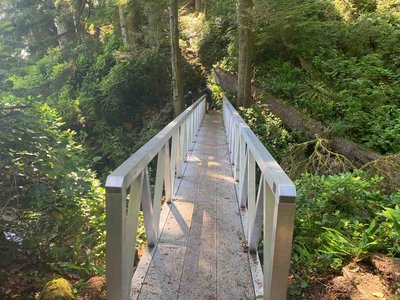

55169__AST_IM_20220720_153434.jpeg

Asset 110139 1 image

Predicted: Steel (conf: N/A)

Actual: Timber

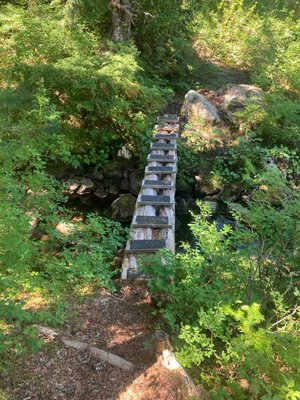

58047__AST_IM_20220806_125731.jpeg

Asset 114635 2 images

Predicted: Steel (conf: N/A)

Actual: Timber

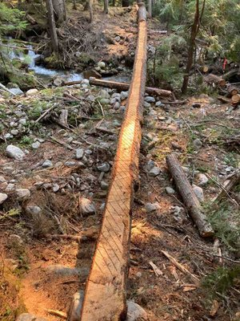

62977__AST_IM_20220910_092600.jpeg

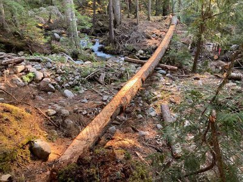

62981__AST_IM_20220910_092613.jpeg

Asset 68016 1 image

Predicted: Steel (conf: N/A)

Actual: Timber

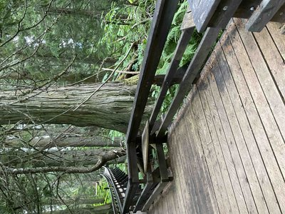

7958__AST_EX_20210725_103041.jpeg

Asset 108353 1 image

Predicted: Steel (conf: N/A)

Actual: Timber

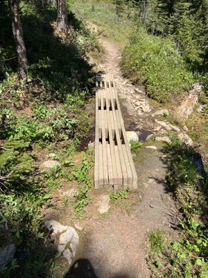

55487__AST_IM_20220715_144400.jpeg

Asset 120681 1 image

Predicted: Timber (conf: N/A)

Actual: Steel

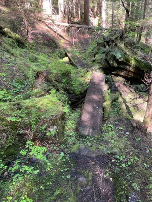

69771__AST_IM_20240606_103254.jpeg

Asset 129378 1 image

Predicted: Timber (conf: N/A)

Actual: Composite

[figure not shown]

92385__AST_EX_20260120_112436.jpeg

Asset 46931 1 image

Predicted: Steel (conf: N/A)

Actual: Timber

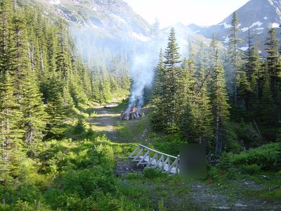

55371__asst_043.jpg

Asset 49063 2 images

Predicted: Steel (conf: N/A)

Actual: Timber

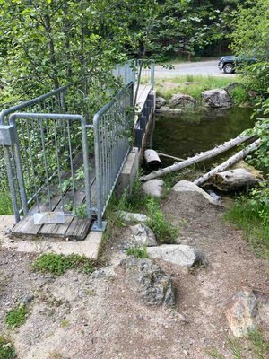

52756__AST_EX_20220707_155645.jpeg

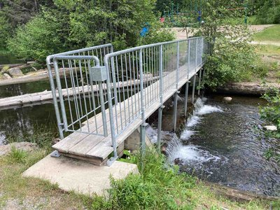

52764__AST_EX_20220707_155352.jpeg

Asset 53195 3 images

Predicted: Timber (conf: N/A)

Actual: Concrete

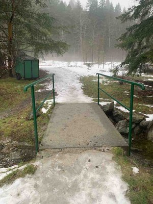

35427__AST_EX_20220113_151616.jpeg

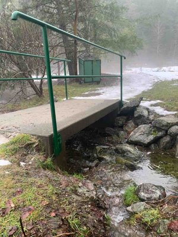

35431__AST_EX_20220113_151626.jpeg

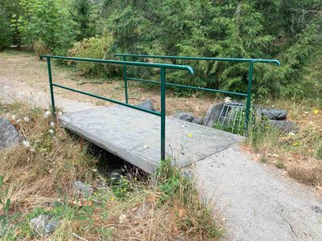

71811__AST_EX_20240730_122826.jpeg

Asset 55633 1 image

Predicted: Steel (conf: N/A)

Actual: Timber

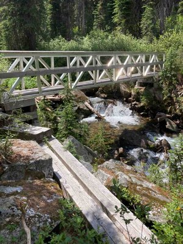

57133__AST_EX_20220729_114550.jpeg